# Homework Solutions

For MATH50XX by ctong

## Q3

### Question

Compared to patients who did not vomit during the day, are patients who experienced emesis during the day less likely to also vomit at night (perhaps due to a more empty stomach)?

### Solution

Patients who did not vomit during the day versus patients who did during the day are two separate groups of people (a person can not *vomit* AND *not vomit*), so we are comparing proportions from 2 independent groups.

*Identify the null and alternate hypotheses*

One-tailed test:

$H_0: \pi_{day \ emesis} \geq \pi_{no \ day \ emesis}$

$H_1: \pi_{day \ emesis} < \pi_{no \ day \ emesis}$

*[Optional] Create fresh copy of data frame*

```r
myDF <- dfHealth
```

*Determine n and x for prop.test()*

```r
# table() creates a contingency table that summarizes the classification of obesrvations across two categorical variables

# dnn argument in the following line of code specifies optional row and column labels for the table
t = table(myDF$Day_Emesis, myDF$Night_Emesis, dnn=c("Day", "Night"))
t
```

```
##    Night
## Day  E  N
##   E 30 11
##   N 50 29
```

```r
n = rowSums(t) # vector of sample sizes
x = t[,"E"] # vector of the number of successes in each sample
```

*Test assumptions*

```r
# Check if number of successes and failures in each group was at least 5 in t
t
```

```
##    Night
## Day  E  N
##   E 30 11
##   N 50 29
```

Each group contains more than 5 successes and 5 failures.

```r
# Check if each sample size is at least 50 in n
n
```

```
##  E  N
## 41 79
```

The sample sizes are 41 and 79 respectively.

```r
# The following code provides a shortcut to compute n1p, n2p, n1(1-p) and n2(1-p)
# All values in the generated table must be at least 5
chisq.test(t)$expected
```

```
##    Night
## Day        E        N
##   E 27.33333 13.66667
##   N 52.66667 26.33333
```

$n_1p, n_2p, n_1(1-p), n_2(1-p)$ are all $\geq 5$.

*Compute sample proportions from contingency table*

```r
prop.table(t, 1) # 1 indicates calculate proportions by row
```

```
##    Night
## Day         E         N
##   E 0.7317073 0.2682927
##   N 0.6329114 0.3670886
```

Based on table generated, we need to compare the proportions 0.73 versus 0.63. Notice that the observerd proportions are actually in the *direction opposite to the question*. It is unlikely that we will get a significant result in the proportions comparison test.

*Perform z-test or Fisher’s Exact Test depending on whether assumptions were met*

One of the two samples only has 41 observations (i.e., fewer than 50). Perform Fisher’s Exact Test.

```r
# recall that the entry in the first row and first column of
# the contingency table is considered a success in the group 1
# therefore, people who experienced ememsis during the day are
# considered group 1, and those who did not are in group 2

fisher.test(t, alternative="less")
```

```
##
##  Fisher's Exact Test for Count Data
##
## data:  t
## p-value = 0.903
## alternative hypothesis: true odds ratio is less than 1
## 95 percent confidence interval:
##  0.000000 3.494026
## sample estimates:
## odds ratio
##   1.575901
```

*Interpret results*

The question did not state a level of significance, so $\alpha$ of .05 will be used.

The results indicate that *p* = .90, which is greater than .05. Therefore, we fail to reject the null that the proportion of patients who experienced emesis during the day is more or equally likely to vomit at night. Conclude that patients who vomited during the day were NOT less likely to vomit at night.

*APA-style results*

Recall that the odds ratio produced by the analysis is an odds ratio

73% of the patients who experienced emesis during the day vomited at night, compared to 63% among patients who did not experience emesis during the day. A Fisher’s Exact test was performed to compare these proportions due to a small sample size for patients who experienced emesis during the day (*n* = 41). The test revealed that patients who experienced emesis during the day were not significantly less likely to vomit at night, compared to those who did not experience emesis during the day, *OR* = 1.58, *p* = .90.

## Q4

### Question

Are patients equally likely to experience emesis and diarrhea during the day?

### Solution

This comparison involves the variables `Day_Emesis` and `Day_Diarrhea`, which are both recorded for *each* patient (i.e., comparison of 2 pieces of data from each patient). The sample proportions being compared are paired (not from independent groups).

*Identify the null and alternate hypotheses*

Two-tailed test:

$H_0: OR = 1$

$H_1: OR \neq 1$

*[Optional] Create fresh copy of data frame*

```r
myDF <- dfHealth
head(myDF)
```

```
##   PID Transportation Day_Diarrhea Day_Emesis Night_Diarrhea Night_Emesis
## 1   1  Not ambulance            D          N              D            N
## 2   2  Not ambulance            D          E              N            E
## 3   3  Not ambulance            N          N              D            E
## 4   4  Not ambulance            N          N              D            E
## 5   5      Ambulance            N          E              N            E
## 6   6  Not ambulance            N          N              N            E
```

*Create contingency table*

```r
t = table(myDF$Day_Emesis, myDF$Day_Diarrhea, dnn = c("Day Emesis", "Day Diarrhea"))
t
```

```
##           Day Diarrhea
## Day Emesis  D  N
##          E 24 17
##          N 44 35
```

b = 17 and c = 44 in the contingency table, so the test will regard **no diarrhea** as **success in V2**, and **no emesis** as **success in V1** if we do not modify the contingency table.

To simplify interpretation, we can use the code below to change the order of the columns and rows to identify **diarrhea** as **success in v2** and **emesis** as **success in v1**.

```r
t = as.table(cbind(t[,"N"],t[,"D"])) # change order of columns
colnames(t)=c("No diarrhea","Diarrhea")
t
```

```
##   No diarrhea Diarrhea
## E          17       24
## N          35       44
```

```r
t = as.table(rbind(t["N",],t["E",])) # change order of rows
rownames(t)=c("No Emesis","Emesis")
t
```

```
##           No diarrhea Diarrhea
## No Emesis          35       44
## Emesis             17       24
```

Now, b = 44 and c = 17. **Diarrhea** will be treated as success in V2, and **Emesis** will be treated as success in V1.

The estimated $OR$ will reflect the relative odds of diarrhea versus emesis.

*Perform Exact McNemar-Type Test*

Run `install.packages("exact2x2")` if you have not installed the `exact2x2` package before.

```r
library(exact2x2)
exact2x2(t,alternative="two.sided",paired=TRUE)
```

```
##
##  Exact McNemar test (with central confidence intervals)
##
## data:  t
## b = 44, c = 17, p-value = 0.0007299
## alternative hypothesis: true odds ratio is not equal to 1
## 95 percent confidence interval:
##  1.449255 4.831853
## sample estimates:
## odds ratio
##   2.588235
```

*Interpret results*

The question did not state a level of significance, so the `p-value` produced by the analysis should be compared against the default $\alpha$ of .05.

The results indicate that *p* < .01, therefore, we reject the null hypothesis that the odds ratio of diarrhea to emesis during the day is equal to 1. Instead, we conclude that patients are not equally likely to experience diarrhea and emesis during the day.

*Compute proportions for reporting*

```r
prop.table(table(myDF$Day_Emesis))
```

```
##
##         E         N
## 0.3416667 0.6583333
```

- 34% of patients experienced emesis during the day. **V1:SUCCESS**
- 66% of patients did not experience emesis during the day. **V1:FAILURE**

```r
prop.table(table(myDF$Day_Diarrhea))
```

```
##
##         D         N
## 0.5666667 0.4333333
```

- 57% of patients experienced diarrhea during the day. **V2:SUCCESS**
- 43% of patients did not experience diarrhea during the day. **V2:FAILURE**

*APA-style results*

During the day, 34% of the patients experienced emesis and 57% experienced diarrhea. An Exact McNemar-Type test revealed that patients were not equally likely to experience emesis and diarrhea during the day, *OR* = 2.59, *p* < .01.

## Q5

### Decision Tree for Test Selection

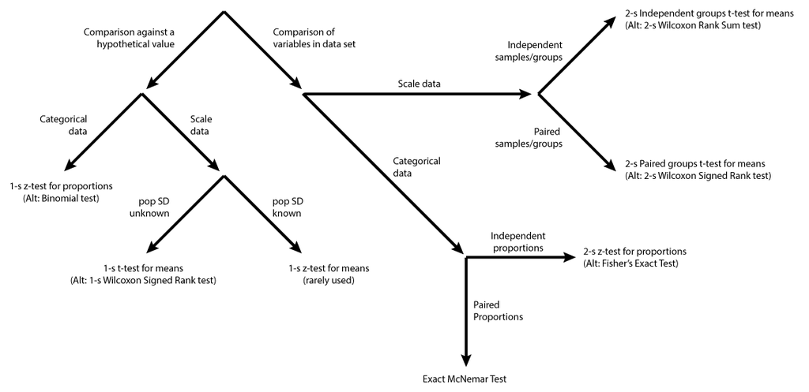